# Using the ‘topicanalysis’-package

Andreas Blätte (andreas.blaette@uni-due.de)

2019-02-27

## Purpose

Using topic models, a text mining technique originally developed for the purposes of information retrieval, has become a common technique in the social sciences (*Computational Social Science : Die Analyse von Big Data* 2018). The original algorithm, ‘latent dirichlet allocation’ (LDA) remains to be the prevalent topic model. Yet while there is a set of quantitative instruments to evaluate a topic model, there are not yet tools readily available for the qualitative evaluation of a topic model. The *topicanalysis* package offers the building blocks to integrate quantitative and qualitative analysis, with a special concern for topic co-occurrences, and time series analysis.

Packages that may supplement the approaches offered here are *stm* and *LDAvis*.

## Getting Started

### Installation

At this stage, the package is only available at GitHub. A CRAN release is not yet planned and/or scheduled. The *devtools*-package offers a convenient function to install the package from GitHub.

```r
devtools::install_github("PolMine/topicanalysis", build_opts = "--no-build-vignettes")
```

### Loading the package

Loading the package should not throw issues or warnings.

```r
library(topicanalysis)
```

```r
library(cwbtools) # available at www.github.com/PolMine/cwbtools
library(polmineR) # CRAN, development version at www.github.com/PolMine/polmineR
```

In the following examples, we will need some further packages.

```r
library(magrittr)
library(xts, quietly = TRUE, warn.conflicts = FALSE, verbose = FALSE) # plotting with nice time-series
library(DT) # nice datatable output
library(RColorBrewer) # nice colors
library(igraph, quietly = TRUE, warn.conflicts = FALSE)
library(data.table)
```

### Make Sample data Available

The package includes a sample LDA topicmodel for Germany’s regional parliament in Berlin (“Berliner Abgeordnetenhaus”) and the Saarland (“Landtag des Saarlands”).

```r
data(package = "topicanalysis")
```

[Lazy loading](https://cran.r-project.org/doc/manuals/r-release/R-ints.html#Lazy-loading) of the data is delibarately not supported, to keep the time to install the package minimal. If we want to use the LDA topic models shipped with the package, we need to activate the data expressively.

```r
data(BE_lda)
data(BE_labels)
```

To inspect/read the full text documents, we need the corpus of the ‘Berliner Abgeordnetenhaus’ (“BE”). It is too large to be included in the *topicanalysis*-package. It is available for download from the PolMine server using the `corpus_install()`-function of the *cwbtools*-package.

The `use()`-function of the *polmineR*-package activates corpora within the *topicanalysis*-package. If the BE corpus is not yet there, it is downloaded and put into the package.

```r
use("topicanalysis")
```

```
## ... activating corpus: BE
```

```r
if (!"BE" %in% corpus()$corpus){
  cwbtools::corpus_install(
    pkg = "topicanalysis",
    tarball = "http://polmine.sowi.uni-due.de/corpora/cwb/berlin/be.tar.gz"
  )
  use("topicanalysis") # to activate corpus 'BE'
}
```

## Classes and Methods

### Generic Methods

The package defines a `cooccurrences()`-method and `read()`-method, building on the original defintion in the *polmineR* package, and a `as.zoo()`-method, originally defined in the *zoo*-package.

#### The `dotplot()`-method

Inspecting the most likels terms for topics is a frequent first step to learn about the (potential) substantive meaning of topics.

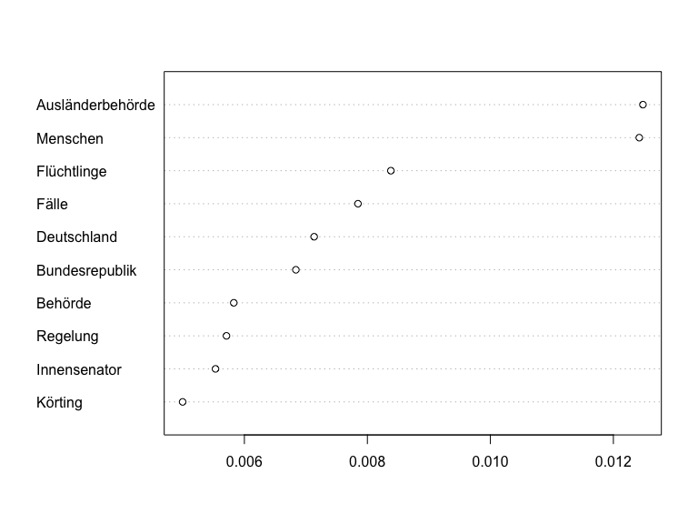

```r
asylum_topic_no <- grep("Asyl", BE_labels)
dotplot(BE_lda, topic = asylum_topic_no, n = 10L)
```

This function is very basic. See the *LDAvis* package for a nicer and more advanced tool to inspect the terms for topics.

#### Time Series Analysis: The `as.zoo()`-method

The `as.zoo()`-method will get the number of occurrences of a topic among the top k topics within a given period (month, quarter, year). The return value is a `zoo` object.

```r
ts_zoo <- topicanalysis::as.zoo(
  BE_lda,
  select = grep("Flucht", BE_labels),
  aggregation = "quarter" # can also be year, month
)
is(ts_zoo)
```

```
## [1] "zoo"
```

The *zoo*-package offers a convenient plotting function for `zoo`-objects.

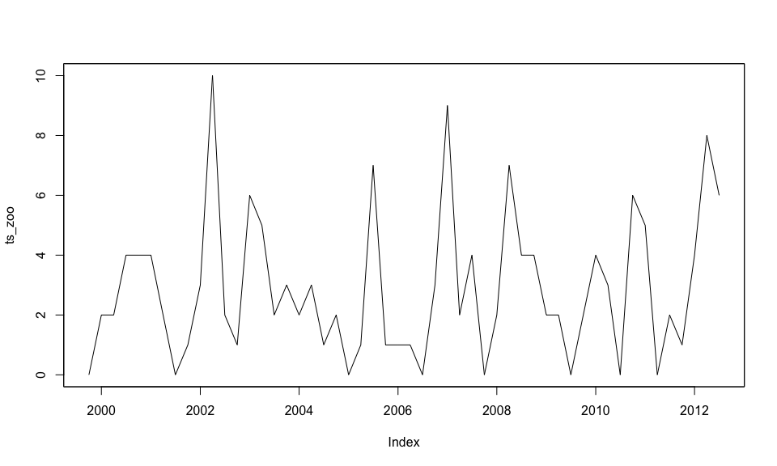

```r
plot(ts_zoo)
```

An alternative is to use the plotting capabilities of the *xts*-package.

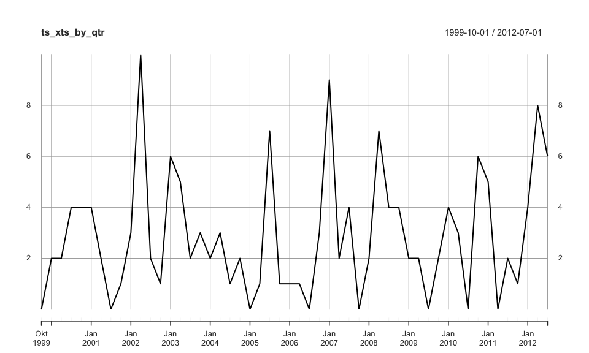

```r
ts_xts_by_qtr <- xts::as.xts(ts_zoo)
plot(ts_xts_by_qtr)
```

#### The `cooccurrences()`-method

A noteworthy feature of the topicmodelling technique is that documents are considered are represented as mixtures of topics. Documents do not fall exclusively in one unique category. Accordingly, the topics co-occur in documents, and it is possible to obtain cooccurrences for topics (cp Gregor Wiedemann). In the *topicanalysis*-package, a `cooccurrences()`-method implements this idea.

```r
dt <- cooccurrences(BE_lda, k = 3L, verbose = FALSE)
head(dt)
```

```
##    a   b count_coi count_ref     exp_coi  chisquare rank_chisquare
## 1: 2   1       124       604  4.38335105 3314.89056              1
## 2: 2  28        72      3785 23.22333107  108.42513              2
## 3: 2 203        59      2906 17.85252181   99.18076              3
## 4: 2   7         2        24  0.15654825   21.84655              4
## 5: 2  73         1         8  0.05418978   16.60977              5
## 6: 2 186         1         9  0.06021087   14.75925              6
```

The topicmodel has been labelled: We drop topics that do not refer to a substantive policy domain or issue, and we add the labels to the table.

```r
topics_to_drop <- grep("^\\(.*?\\)$", BE_labels)
dt_min <- dt[chisquare >= 10.83][!a %in% topics_to_drop][!b %in% topics_to_drop]
DT::datatable(dt_min)
```

|  | a | b | count_coi | count_ref | exp_coi | chisquare | rank_chisquare |
| --- | --- | --- | --- | --- | --- | --- | --- |
| 1 | 9 | 54 | 6 | 137 | 0.949240725315563 | 27.1035410738249 | 3 |
| 2 | 9 | 180 | 6 | 160 | 1.10191580700968 | 21.9645036728398 | 4 |
| 3 | 16 | 86 | 6 | 380 | 0.651326890627397 | 44.2155245736348 | 1 |
| 4 | 37 | 218 | 54 | 775 | 3.37392973699366 | 770.931777956303 | 1 |
| 5 | 40 | 109 | 6 | 272 | 1.14568748160188 | 20.7267300571726 | 3 |
| 6 | 44 | 218 | 52 | 777 | 11.2786214878159 | 150.658164740036 | 1 |
| 7 | 44 | 74 | 10 | 149 | 2.1632096701601 | 28.8413705790822 | 5 |
| 8 | 44 | 11 | 13 | 331 | 4.6801517392143 | 15.0607103271898 | 7 |
| 9 | 44 | 113 | 12 | 331 | 4.66654664694914 | 11.7351980947743 | 8 |
| 10 | 46 | 201 | 5 | 192 | 1.00398232921442 | 16.0267193451923 | 6 |

[output cut: 142 more lines]

Let us pimp the table somewhat to have labels, not integer ids for topics.

```r
dt_min[, "a_label" := BE_labels[ dt_min[["a"]] ] ]
dt_min[, "b_label" := BE_labels[ dt_min[["b"]] ] ]
dt_min[, "a" := NULL]
dt_min[, "b" := NULL]
dt_min[, "rank_chisquare" := NULL]
setcolorder(dt_min, neworder = c("a_label", "b_label", "count_coi", "count_ref", "exp_coi", "chisquare"))
DT::datatable(dt_min)
```

|  | a_label | b_label | count_coi | count_ref | exp_coi | chisquare |
| --- | --- | --- | --- | --- | --- | --- |
| 1 | Diskriminierung aufgrund des Geschlechts oder der sexuellen Orientierung | Industriepolitik | 6 | 137 | 0.949240725315563 | 27.1035410738249 |
| 2 | Diskriminierung aufgrund des Geschlechts oder der sexuellen Orientierung | Berufsausbildung | 6 | 160 | 1.10191580700968 | 21.9645036728398 |
| 3 | Beziehungen zwischen den staatlichen Gewalten (Legislative, Judikative, Exekutive), Verwaltungsangelegenheiten und Verfassungsreformen | Staatshaushalt und -verschuldung | 6 | 380 | 0.651326890627397 | 44.2155245736348 |
| 4 | Grundschule und weiterbildende Schulen | Grundschule und weiterbildende Schulen | 54 | 775 | 3.37392973699366 | 770.931777956303 |
| 5 | Industriepolitik | Staatsdienst/ Beamtentum | 6 | 272 | 1.14568748160188 | 20.7267300571726 |
| 6 | Mutterschutz, Elternzeit und Kinderbetreuung | Grundschule und weiterbildende Schulen | 52 | 777 | 11.2786214878159 | 150.658164740036 |
| 7 | Mutterschutz, Elternzeit und Kinderbetreuung | Bildung (Sonstiges) | 10 | 149 | 2.1632096701601 | 28.8413705790822 |
| 8 | Mutterschutz, Elternzeit und Kinderbetreuung | Mutterschutz, Elternzeit und Kinderbetreuung | 13 | 331 | 4.6801517392143 | 15.0607103271898 |
| 9 | Mutterschutz, Elternzeit und Kinderbetreuung | Staatshaushalt und -verschuldung | 12 | 331 | 4.66654664694914 | 11.7351980947743 |
| 10 | Unterstützung von Senioren und Rente (einschließlich staatliche Pensionen) | Pharmaunternehmen, medizinische Geräte und laboratorischen Kliniken | 5 | 192 | 1.00398232921442 | 16.0267193451923 |

[output cut: 142 more lines]

#### The `read()`-method

Documents are mixtures of topics. Blei conveyed this idea in his classic article using a short text, highlighting with different colors the most likely terms for the topics present in this document.

The result can be achieved using the `read()`-method, applied on a TopicModel class object.

```r
p <- partition("BE", date = "2005-04-28", who = "Körting", verbose = FALSE)
ek <- as.speeches(p, s_attribute_name = "who", verbose = FALSE)[[4]]
```

The `read()`-method is designed to be used in an interactive session.

```r
if (interactive()) read(BE_lda, ek, no_token = 150)
```

To include a document into a Rmarkdown document (such as this vignette), we use the worker function `get_highlight_list()` and use the returned list as input for a combination of `html()` and `highlight()`.

```r
h <- get_highlight_list(BE_lda, partition_obj = ek, no_token = 150)
html(p, height = "350px") %>%
  highlight(highlight = h)
```

## Corpus: BE

### date: 2005-04-28 // who: Körting

Herr Präsident! Meine Damen und Herren! Ich beginne mit der Frage des Kollegen Henkel. – Herr Kollege Henkel! Ihre Frage nimmt offenbar Bezug auf das Zahlenmaterial des vom Bundeskriminalamt durchgeführten Auswerteprojektes Wostok. Bei den im Rahmen dieses Projekts bekannt gewordenen Vertriebspartnern, der so genannten Reiseschutz AG, ist Berlin zahlenmäßig am stärksten vertreten. Ich weise darauf hin, dass ich bereits auf die Mündliche Anfrage des Kollegen Ritzmann am 24. Februar 2004 geantwortet habe, dass eine erhebliche Anzahl entsprechender Büros in Berlin vertreten ist. Es ist wichtig darauf hinzuweisen, dass das Wostok-Projekt einerseits nur einen Teilbereich der Schleuserkriminalität betrachtet, andererseits die Daten beziehungsweise Zahlen keinen Rückschluss darauf zulassen, dass gegen alle erfassten Firmen und Geschäftsleute hinreichende tatsächliche Anhaltspunkte für die Begehung einer Straftat und damit für die Einleitung eines Ermittlungsverfahrens vorlagen bzw. vorliegen. In dem Datensatz wird zunächst einmal erfasst, welche Büros von der Möglichkeit der so genannten Reiseschutzpässe, die immerhin von der größten deutschen Versicherungsgesellschaft versichert worden sind, Gebrauch gemacht haben. Das Landeskriminalamt hat einerseits das ihm verfügbare Zahlenmaterial über die hier eingeleiteten 25 Ermittlungsverfahren in diesen Tatkomplex in das Auswerteprojekt eingespeist, andererseits einen Zwischenbericht und auch die mittlerweile vorliegende zweite Fassung des Projektberichts darauf hin ausgewertet, ob sich aus den insgesamt 87 Datensätzen – das heißt, 87 Reisebüros oder Unternehmen in Berlin, die von diesen Reiseschutzpässen Gebrauch gemacht haben – die Notwendigkeit ergibt, weitere Verfahren einzuleiten. Zu Ihrer zweiten Frage: Die Auswertung der Bundeslagebilder 2001 und 2003 zu dem Themenkomplex ergibt, dass Berlin bei der Zahl der Schleusungsfälle auf den Plätzen zwei bis vier und bei den qualifizierten Schleusungen auf den Plätzen fünf bis zehn liegt. Ich habe schon früher darauf hingewiesen, dass die Zahlen der Kriminalstatistik gerade in diesem Bereich einerseits mit der konsequenten Schwerpunktsetzung des hiesigen Landeskriminalamtes, das eine weithin anerkannte Arbeit leistet, zu tun haben, wie auch mit der besonderen Belastung Berlins auf Grund seiner geographischen Lage im Schnittpunkt zwischen Ost und West. Nun zur Frage des Kollegen Ritzmann: Es sei mir gestattet, Herr Kollege Ritzmann, darauf hinzuweisen, dass es keiner Berichte des Bundeskriminalamts bedarf, um die Innenverwaltung und auch mich davon zu unterrichten, dass wir ein besonderes Problem mit Schleusungskriminalität in Berlin haben. Ich selbst habe verschiedentlich die Öffentlichkeit darüber unterrichtet. Ich erinnere an den von der Justizsenatorin und mir vorgestellten Lagebericht zur organisierten Kriminalität des Jahres 2002, in dem wir besonders auf die Schleusungskriminalität unter anderem auch unter anderem auch unter Nutzung von Reisebüros eingegangen sind. Der Bericht des Bundeskriminalamtes aus dem Jahr 2004 mit dem Titel “ Sonderauswertung Wostok über Schleusungen unter missbräuchlicher Verwendung von Reiseschutzpässen ” ist der Innenverwaltung am 25. April 2005 zugänglich gemacht und durch mich zur Kenntnis genommen worden. Ein Entwurf ist dem Landeskriminalamt Berlin Ende 2003 durch das Bundeskriminalamt übermittelt worden und hat dazu geführt – das habe ich auf die Frage des Kollegen Henkel bereits dargestellt –, dass das Landeskriminalamt die von ihm selbst eingeleiteten 25 Ermittlungsverfahren mit dem Bericht abgeglichen und bei den übrigen Verfahren im Jahr 2003 keinen Anlass für einen Anfangsverdacht gegenüber Sonstigen gesehen hat. Vielleicht muss man das dahin gehend ergänzen, dass der Bericht neben den 25 von Berlin geführten Verfahren weitere 15 bis 20 Verfahren enthält – Verfahren, also nicht nur Reisebüronennungen –, die von der Staatsanwaltschaft Berlin auf Grund von Zulieferung der Bundesgrenzschutzdirektionen beziehungsweise anderer Staatsanwaltschaften geführt werden. Herr Kollege Henkel! Wir haben eine Zuständigkeit des Landeskriminalamtes im Referat 22, das sich spezifisch mit Schleusungskriminalität befasst. Wir haben Schleusungskriminaltität in verschiedensten Erscheinungsformen. Wir haben die jetzt öffentlich geführte Debatte über Schleusungskriminalität mit diesen so genannten Reiseschutzpässen. Wir haben darüber hinaus eine Schleusungskriminalität mit Einladungen, die fingiert sind und wo es Verpflichtungserklärungen der Einladenden für die Sicherstellung der Rückkehr der eingeladenen Personen gibt. Und wir haben insbesondere im letzten Jahr eine neue Form der Schleusungskriminalität im Fokus des Landeskriminalamtes. Das sind diejenigen, die insbesondere auch aus dem Bereich China hierher kommen – als Studenten, die sich angeblich durch deutsche Sprachkurse vorbereiten –, wobei die Sprachkurse nach den Erkenntnissen des Landeskriminalamtes und nach den durchgeführten Ermittlungsverfahren nur vorgeschoben sind. Wir haben also verschiedenste Formen der Schleusungskriminalität. Ich bin gern bereit, noch einmal durch die zuständigen Institutionen – Polizeipräsident und Landeskriminalamt – überprüfen zu lassen, ob unsere Aufstellung optimal ist. Bisher habe ich den Eindruck, dass das Landeskriminalamt eine anerkannt gute Arbeit auch bei der Aufdeckung von Schleusungskriminalität leistet, was z. B. durch die 25 Fälle, die ich genannt habe, dokumentiert wird, denn diese Ermittlungsverfahren des Landes Berlin sind völlig unabhängig von dem Auswerteprojekt des Bundes erfolgt. Diese Verfahren wurden in den Jahren 2001 und 2002 eingeleitet – bis auf zwei, die erst im Jahr 2004 eingeleitet wurden –, und diese Verfahren sind abgeschlossen und liegen der Staatsanwaltschaft vor. Teilweise hat es dort auch schon zu entsprechenden Abschlüssen bei der Staatsanwaltschaft geführt – je nach Sachlage mit Strafbefehl, Anklageerhebung oder auch Einstellung des Verfahrens. Herr Kollege Ritzmann! Sie erwecken einen falschen Eindruck. -LSB- Wansner -LRB- CDU -RRB-: Nein, nein! -RSB- Die Schleusungskriminalität ist eine besondere Kriminalitätsform, die teilweise mit organisierter Kriminalität zusammenhängt, und deswegen haben wir in der Kriminalitätsbekämpfung auch einen Schwerpunkt bei Schleusungskriminalität. Dazu hat das Land Berlin durch sein Landeskriminalamt und durch die Polizei eine Vielzahl von Ermittlungsverfahren durchgeführt, über die ich als Person auch teilweise unterrichtet bin, und zwar laufend seit 2001 durch entsprechende Lagebilder oder Ähnliches. -LSB- Niedergesäß -LRB- CDU -RRB-: Lange geschlafen! -RSB- – Herr Kollege Niedergesäß! Auf diese Verfahren hin ist von der Berliner Polizei ermittelt worden, und in den Jahren 2001, 2002 und 2003 sind Ermittlungen abgeschlossen und an die Staatsanwaltschaft weitergegeben worden. Sie können ja sagen, Sie machen irgendetwas gegen mich.. Das haben Sie umsonst. Aber ich empfinde es als schlichtweg niederträchtig gegenüber den Mitarbeitern meiner Polizei, -LSB- Ah! von der CDU -RSB- die dort seit Jahren ermitteln und entsprechende Verfahren machen, wenn man sagt, sie hätten geschlafen – -LSB- Beifall bei der SPD und der PDS -RSB- bei aller Liebe zur politischen Polemik. Die Polizei ist an der Thematik seit Jahren dran, ermittelt – – -LSB- Dr. Lindner -LRB- FDP -RRB-: Der zuständige Senator aber nicht! – Henkel -LRB- CDU -RRB-: Der Senator nicht! – Weitere Zurufe -RSB- – Herr Kollege Lindner! Ich habe etwas dazu gesagt. Wir haben diese Problematik thematisiert. Wenn Sie sich in den letzten Jahren, wo Frau Schubert und ich das gemacht haben, mit dieser Problematik – der organisierten Kriminalität, den Lagebildern und diesen Fragen – nicht auseinander gesetzt haben, dann tut es mir Leid. Dann müssten Sie einmal nachlesen, was wir in den letzten Jahren dazu gesagt haben. -LSB- Beifall bei der SPD und der PDS -RSB- Der Wostok-Bericht selber – auch das muss man sagen – ist nicht etwa ein Ermittlungsverfahren des Bundeskriminalamtes, sondern er ist die statistische Zusammenfassung und Auswertung dessen, was in den Ländern gelaufen ist, so dass sich im Wostok-Bericht im Grunde nur das wiederfindet, was auch vom Land Berlin an Ermittlungsverfahren zugeliefert wurde, weil diese Ermittlungsverfahren hier bei uns gelaufen sind. Zusätzlich haben wir über den Wostok-Bericht Büronamen erfahren, die mit Reiseschutzpässen gehandelt haben. Herr Ritzmann, jetzt können Sie sagen, Sie hielten das mit den Reiseschutzpässen für nicht in Ordnung. Das ist Ihr gutes politisches Recht. -LSB- Frau Dr. Klotz -LRB- Grüne -RRB-: Das war Kinkel! – Dr. Lindner -LRB- FDP -RRB-: Blödsinn! Es ist doch dann erst angestiegen! -RSB- Aber Sie müssen einfach sehen, dass diese Form der Tourismusvermittlung nicht illegal gewesen, sondern ausdrücklich zugelassen worden ist. Ja, es gibt auch viele Leute, die die Sicherstellung der Rückführung der Leute durch eine Versicherung im Grunde für eine vernünftige Regelung halten. Diese vernünftige Regelung gibt es seit dem Jahr 2003 nicht mehr, und zwar deshalb – auch darauf habe ich am 24. Februar hingewiesen –, weil auch wir vom Senat dieses Verfahren mit den Reiseschutzpässen für missbrauchsanfällig gehalten haben. Es hat auch entsprechend zu Missbräuchen geführt. Das ist auch der Grund, warum der Bund und das Auswärtige Amt im März 2003 die entsprechenden Konsequenzen gezogen haben. Herr Kollege Ratzmann! Ich bewerte nicht die Aussage von Menschen vor einem Untersuchungsausschuss – auch nicht vor dem Bundestag. Es gibt eine politisch unterschiedliche Wertung der Vorgänge. Dabei sollte man es aber auch belassen. Es gibt eine unterschiedliche Wertung: Die Opposition bewertet dieses Verfahren mit den Reiseschutzpässen anders, als es die Bundesregierung bewertet hat. Wir können allerdings nicht wegdiskutieren, dass es in diesem Bereich dann durch eine gutgemeinte Reiseschutzpassinitiative auch einen Missbrauch gegeben hat. Den gibt es übrigens in allen anderen Bereichen auch. Den gibt es auch in der sonstigen Schleusungskriminalität. -LSB- Dr. Lindner -LRB- FDP -RRB-: Aber da war er politisch gewollt! -RSB- – Herr Kollege Lindner! Wenn Sie in das Ausland reisen – und ich bin auch einige Mal außerhalb von Berlin gewesen –, dann ist es üblicherweise so, dass ich nicht zur Botschaft des fremden Staates, sondern in ein Reisebüro gehe, -LSB- Henkel -LRB- CDU -RRB-: Wo fahren Sie denn hin? -RSB- meine Reise buche und dort im Reisebüro dann, wenn Visumpflicht besteht, den entsprechenden Visumsantrag ausfülle. -LSB- Henkel -LRB- CDU -RRB-: Und einen Reiseschutzpass bekommen! -RSB- – Nein, keinen Reiseschutzpass! – -LSB- Henkel -LRB- CDU -RRB-: Aha! -RSB- Das ist das international übliche Verfahren. Aber auch dieses Verfahren – das hat mit der Wostok-Problematik überhaupt nichts zu tun – hat in einer Vielzahl von Fällen zu Missbräuchen geführt, weil die Reisebüros dann entsprechend bei bestimmten Reisen falsche Erklärungen und falsche Verpflichtungserklärungen abgegeben haben. Auch dazu ermittelt die Berliner Polizei und die Berliner Staatsanwaltschaft. Solange es diesen Migrationsdruck aus osteuropäischen oder asiatischen Ländern gibt, wird es immer wieder den Versuch von Kriminellen geben, die Verfahren, die wir haben und die vom Grundsatz her liberal sein sollen, zu missbrauchen. Wir haben alle gemeinsam einmal gesagt, dass wir froh sind, dass der Eiserne Vorhang weg ist, und wir sollten es nicht vernachlässigen, dass wir das einmal gesagt haben. Diese liberalen Verfahren führen selbstverständlich auch dazu, dass Menschen diese Verfahren missbrauchen – ob das nun der Reiseschutzpass ist, das Einladungsverfahren, Studienaufenthalte oder Ähnliches. Das haben wir zu allen Zeiten gehabt, und das werden wir auch nicht wegdiskutieren können. -LSB- Dr. Lindner -LRB- FDP -RRB-: Sie haben das billigend in Kauf genommen! – Ratzmann -LRB- Grüne -RRB-: Langsam reicht es. Passen Sie auf, was Sie sagen! -RSB- Unsere Aufgabe wird es sein, dort immer wieder einzuhaken und immer wieder Ermittlungen dagegen zu führen, um derartige Dinge auszutrocknen. -LSB- Beifall bei der SPD -RSB- Herr Kollege Felgentreu! Die entsprechende Handhabung in den Botschaften ist im März 2003 geändert worden, so dass inzwischen eine andere Handhabung bei der Erteilung von Visen existiert. Wir haben nach wie vor in erheblichem Umfang Schleusungskriminalität. Ich weise darauf hin, dass wir von 2003 auf 2004, als es das Verfahren bereits nicht mehr gab, einen Zugang von 226 % haben. Das betrifft insbesondere auch Ermittlungsverfahren hinsichtlich chinesischer Schleusungen. Diese Personen halten sich auf Grund von angeblichen Sprachstudien oder ähnlichem in der Bundesrepublik auf. Wir haben nun festgestellt, dass diese Sprachvorbereitung nur vorgeschützt waren. -LSB- Ritzmann -LRB- FDP -RRB-: Wie viele Fälle waren es? -RSB- – Es sind jetzt 140 oder 160 Fälle, die wir im Jahr 2004 hatten. Das ist – Sie haben es selbst genannt, Herr Ritzmann – eine Steigerung um 226 %. Das hat nur nichts mit Wostok zu tun. Das ist ein völlig anderes Verfahren. Das muss man nüchtern betrachten. Die Schwerpunktsetzung Schleusung beim Landeskriminalamt ist deshalb nach wie vor berechtigt. Nach Einschätzung meiner Mitarbeiter bedarf es dazu nicht etwa des Einsatzes einer gesonderten Ermittlungsgruppe. Die Aufgabenverteilung innerhalb des Landeskriminalamtes gewährleistet, dass dort der Schwerpunkt auch schwerpunktmäßig behandelt wird. Herr Präsident! Frau Kollegin Villbrandt! Zur Zeit nehmen elf Abschiebehäftlinge die amtlich angebotene Nahrung nicht an. Ob sie im Hungerstreik sind, lasse ich dahinstehen, weil eine private Eigenversorgung durch Nahrungs - und Genussmittel natürlich möglich ist und von uns auch nicht kontrolliert werden kann, da keine Einzelbewachung stattfindet. Diese Häftlinge haben sich in einem Schreiben über folgende Punkte beklagt: Erstens haben sie sich über die rechtlichen Vorschriften des Aufenthalts - und Zuwanderungsrechts beklagt; zweitens über lange Wartezeiten bei der Bearbeitung von Einzelfällen durch die Ausländerbehörde; drittens über angebliche körperliche Übergriffe auf Häftlinge, Verletzungen der Menschenrechte sowie eine mangelhafte ärztliche Versorgung. Soweit es die rechtlichen Bestimmungen des Aufenthalts - und Asylverfahrensrechts betrifft, sind diese bindend. Soweit es die anderen Fragen betrifft, hat eine Überprüfung stattgefunden, die keine Hinweise auf eine Bestätigung der formulierten Behauptungen brachte. Der zweite Punkt ist die palästinensische Herkunft mit ungeklärter Staatsangehörigkeit. Nach geltender Weisungslage werden keine Haftanträge für Palästinenser und Kurden aus dem Libanon gestellt, soweit ihre Identität feststeht und solange sie nicht im Besitz eines gültigen Dokuments de voyage sind. Das ist die geltende Lage. Allerdings gilt eine Ausnahme dann, wenn wir Abschiebungen im Wege der Amtshilfe für andere Behörden machen. Dann wird die Abschiebehaft auch bei uns für andere Behörden vollzogen. Die Ausländerbehörde wird dann von unserer Verfahrenspraxis in Kenntnis gesetzt – das ist dann eine andere, das ist nicht die Berliner Ausländerbehörde –, und sie muss darauf hingewiesen werden, dass sie die entsprechenden Dokumente vorlegt, sonst werden die Betreffenden von uns aus der Abschiebehaft entlassen. Eine völlige Freistellung von Palästinensern von einer möglichen Abschiebung gibt es de facto auch heute nicht. Die libanesische Botschaft hat im Jahr 2004 für drei Palästinenser entsprechende Dokumente ausgestellt, so dass die Abschiebungsvoraussetzungen erfüllt waren. Auch im Jahr 2005 hat die libanesische Botschaft für einen Palästinenser ein entsprechendes Dokument ausgestellt und für einen zweiten Palästinenser eine Passzusage erteilt. Das heißt, man kann nicht mit absoluter Klarheit sagen, für Palästinenser kann es in keinem Fall eine Abschiebung in den Libanon geben, das ist eine Frage des Einzelfalls. Im Regelfall haben Sie Recht, dass der Libanon sich schwer tut mit der Rücknahme von Palästinensern und dass deshalb im Regelfall – wenn für uns die Frage klar ist – natürlich auch keine Abschiebehaft verhängt wird. Unsere Praxis hat im Moment mit dem Rücknahmeabkommen, das beabsichtigt oder ausgehandelt ist, aber noch nicht unterschrieben worden ist, noch nichts zu tun. Wenn es ein derartiges Rücknahmeabkommen gibt, existiert eine neue Situation. Im Regelfall gehen wir davon aus, dass Palästinenser nicht in Abschiebehaft genommen werden. Aber außerhalb dieses Regelfalls gibt es jedoch Fälle, zum Beispiel solche, wo wir Zweifel an der Identität und Zweifel an der Behauptung haben, denen wir nachgehen, und wenn diese Zweifel geklärt sind, wird sofort aus der Abschiebehaft entlassen. Aber die bloße Behauptung, wenn wir jemanden aufgreifen: Ich bin Palästinenser, deshalb darf ich nicht in Abschiebehaft! –, reicht nicht. Es muss eine klare Sachverhaltsaufklärung sein, um von Seiten der Ausländerbehörde den Fall entscheiden zu können. Wenn wir ein Abkommen ratifiziert oder unterschrieben bekommen, ergibt sich eine neue Situation auch für die Rückführung von Palästinensern in den Libanon. Aber das auch nur für den Zeitraum derjenigen, die neu kommen bzw. ab dem Jahr 200 gekommen sind. Herr Kollege Ratzmann! Als im Vermittlungsausschuss auch bundesratsseitig diskutiert wurde, wie wir mit dem Zuwanderungsgesetz umgehen, spielte die Frage eine nicht unwichtige Rolle, wie man mit Kettenduldungen, mit Leuten, für die es keine Dokument gibt, mit denjenigen, die in einem Staat nicht wieder angenommen werden, umgeht. Das betraf insbesondere Palästinenser aus dem Libanon. Deshalb hat man sich beim Zuwanderungsgesetz auf den § 25 Abs. 5 verständigt, der sagt: Wenn feststeht, dass die Rückführung tatsächlich nicht möglich ist, dann sollen die Leute hier auch nicht sozusagen auf einem Wartestand über viele Jahre gehalten werden, sondern dann soll man ihnen auch eine Aufenthaltserlaubnis geben. Das war der Konsens, den wir im Vermittlungsausschuss gehabt haben. Der wird jetzt gegenzuchecken sein, wenn das feststeht mit dem beabsichtigten Abkommen zwischen der Bundesrepublik und der Republik Libanon. Das hängt aber davon ab, was dort im Einzelnen nachher unterschrieben wird. Bisher ist mir bekannt, dass beabsichtigt ist, alle neuen Fälle zu nehmen, also alle, die jetzt kommen, zurückzunehmen. Weiter ist mir bekannt, dass man auch Altfälle ab dem Jahr 2000 zurücknimmt, aber nicht davor. Aber, wie gesagt, das Abkommen ist nicht unterschrieben, das Abkommen ist nicht ratifiziert, wir müssen abwarten, was letztlich herauskommt. Herr Präsident! Herr Kollege Felgentreu! Ich halte den Erfolg, den die Kriminalpolizei gestern durch den Vollzug von fünf Haftbefehlen gegenüber Drogenhändlern erreicht hat, darunter ein stadtbekannter Mensch, der sich selbst als Präsident bezeichnet und der nach dem, was ihm vorgeworfen wird, eine der führenden Funktionen innerhalb der organisierten Kriminalität Berlins innehat, für hervorragend. Ich halte das für ein hervorragendes Ergebnis der Berliner Polizei, dass diese Leute aus dem Verkehr gezogen wurden und insbesondere damit auch ein deutliches Zeichen gegenüber organisierter Kriminalität in der Stadt gesetzt wurde. -LSB- Beifall bei der SPD und der PDS – Vereinzelter Beifall bei der FDP -RSB- Herr Kollege Dr. Felgentreu! Der Betreffende hat mehrere Freiheitsstrafen bekommen und auch verbüßt. Wir haben seinerzeit versucht, ihn nach Verbüßung der letzten Freiheitsstrafe – er ist türkischer Staatsangehöriger gewesen – in die Türkei abzuschieben. Das ist nach dem geltenden Ausländerrecht bei einer Freiheitsstrafe von mehr als drei Jahren ohne weiteres möglich. Wir haben aber die Sondersituation, dass die Türkei in diesem Fall und in einer Reihe von anderen Fällen, die alle ähnlich gelagert sind und diesen Clan betreffen, vor Durchführung der Abschiebemaßnahme die Betreffenden zwangsweise aus der türkischen Staatsangehörigkeit entlassen hat, und zwar mit der Begründung, dass diese Staatsangehörigen den Wehrdienst in der Türkei verweigert hätten und es in der Türkei ein Gesetz gebe, wer den Wehrdienst nicht leiste, verliere die türkische Staatsangehörigkeit. Das betraf nicht nur Mahmoud Al-Z., sondern auch einen Onkel von ihm, der 58 Jahre alt war, wo man sich schon fragen muss, was er noch mit Wehrpflicht in der Türkei zu tun hat, wenn er im Jahr 2002 dort ausgebürgert wird. Diese und andere Fälle haben zu Protesten meinerseits und auch zu Protesten des Bundesinnenministers gegenüber dem türkischen Innenminister geführt. Die türkische Regierung hat zugesagt, dass sie das Gesetz über diese Ausbürgerungsfälle ändern werde. Sie hat es leider bis heute nicht geändert. Ich hoffe, dass die Türkei kurzfristig zu ihrer Zusage steht. Herr Kollege Wansner! Ich habe keine Verhandlungen mit den Nutzern des Hauses Yorckstraße 59 geführt. Ich habe, nachdem diese Nutzer das Rathaus Kreuzberg in einem größeren Teilnehmerkreis betreten hatten, auf Bitten der zuständigen Bezirksbürgermeisterin mit den Nutzern gesprochen. In der Yorckstraße 59 gab es einen Streit einerseits der Nutzer und andererseits der Hauseigentümer über die angemessene Miete. Bei diesem Streit hat man sich nicht verständigen können. Die Nutzer waren der Meinung, sie müssten 2,39 \( pro Quadratmeter zahlen, und ein Schiedsgutachten, das eingeholt wurde, sagte, sie müssten 3,74 zahlen. Daraufhin haben die Nutzer trotzdem gesagt, sie zahlten diese Miete nicht. Daraufhin hat der Hauseigentümer das getan, was man in einem geordneten Staatswesen tut: Man klagt. -LSB- Frau Oesterheld -LRB- Grüne -RRB-: Na, na, der wollte ja wohl eine andere Summe haben! -RSB- – Nein, er hat ihnen 3,74 angeboten, und dann hat er geklagt. – Bei der Klage hat er in allen Fällen, so weit es mir bekannt ist, entsprechende Räumungstitel gegenüber den Nutzern erwirkt. Ich habe denen gesagt, das sei ein Zivilrechtsstreit, mit dem das Land Berlin nichts zu tun habe. Ich habe auch gesagt, ich könne mir vorstellen, dass es andere Lösungen gebe, ich hielte die aber für ausgeschlossen. Das habe ich den Nutzern sehr klar gesagt. Ich halte es für ausgeschlossen, dass das Land Berlin etwa dieses Haus kauft, um es dann mit Verlusten weiterzuvermieten. Das kann keiner verantworten. Das habe ich denen klipp und klar gesagt und habe ihnen geraten, weil alle offensichtlich wohlwollend sind, bis hin zu Herrn Wansner: Wenn alle Beteiligten guten Willens sind, nutzt doch diesen guten Willen, euch vernünftige Ersatzquartiere zu suchen! – Dieser mein Hinweis scheint nicht auf besonders fruchtbaren Boden gefallen zu sein. Herr Kollege Wansner! Ich habe keine Veranlassung gehabt, mich mit den Menschen, mit denen ich mich da unterhalten habe, über später, nach der Unterhaltung, stattfindende Straftaten zu unterhalten, sondern ich bin von der Bezirksbürgermeisterin dorthin gerufen worden, die gesagt hat, die seien gekommen und sie stelle keinen Antrag wegen Hausfriedensbruchs. Das heißt, ein Straftatbestand liegt im Betreten des Rathauses an sich noch nicht vor, wie bei vielen Bürgern. -LSB- Heiterkeit und Beifall bei der SPD und der PDS -RSB- Dementsprechend hatte ich keine Veranlassung, darüber mit ihnen zu reden. Ich kann Ihnen aber klipp und klar sagen, dass ich meine Rechtsauffassung zu bestimmten Dingen deutlich gemacht habe. Ich habe den Beteiligten auch gesagt, sie sollten sich durch ihr Verhalten nicht unglücklich machen, etwa indem sie sich im Rahmen späterer Räumungsaktionen strafbar machten oder indem sie sich durch Provozierung einer Räumung Schadenersatzprozessen des Hauseigentümers aussetzten. Ich nehme da kein Blatt vor den Mund und habe es ihnen da genauso deutlich gesagt, wie ich es hier sage. Herr Kollege Hahn! Das erfolgt auf der Grundlage des Staatsangehörigkeitsregelungsgesetzes und des geltenden Aufenthaltsrechts. -LSB- Beifall bei der SPD und der PDS -RSB- Herr Kollege Hahn! Da müssen Sie etwas missverstanden haben. -LSB- Hahn -LRB- FDP -RRB-: Meldung der “ taz ”! -RSB- Der Bundesinnenminister kann keinem Menschen die deutsche Staatsangehörigkeit entziehen. Dafür hat er keine Zuständigkeit. Das betrifft übrigens nicht nur Türken, sondern auch Menschen, die mit Amerikanern verheiratet sind, deshalb die amerikanische Staatsangehörigkeit angenommen haben und jetzt zu ihrer Überraschung feststellen, dass sie gleichzeitig die deutsche verloren haben. Man verliert nach dem geltenden Recht, wenn man eine fremde Staatsangehörigkeit annimmt, automatisch die deutsche Staatsangehörigkeit. Da brauche ich keine Entziehung oder wie auch immer. Was der Bundesinnenminister gemacht hat, ist die Bitte an die türkischen Behörden, nachdem bekannt geworden ist, dass es eine Vielzahl von ehemals türkischen Staatsangehörigen, die Deutsche geworden sind, gegeben hat, die dann wieder – wie das früher möglich war – die türkische Staatsangehörigkeit zusätzlich erworben haben, den deutschen Behörden dieses bekannt zu geben, damit man dann mit den Betreffenden über die notwendigen Folgerungen reden kann. Teilweise sieht das Aufenthaltsrecht übrigens, was den Aufenthaltsstatus betrifft, ausdrückliche Vergünstigungen vor. Ehemalige deutsche Staatsangehörige, die die deutsche Staatsangehörigkeit abgelegt haben, haben nach dem Aufenthaltsrecht ein leichteres Verfahren zum Erwerb einer Aufenthaltserlaubnis oder einer Niederlassungserlaubnis. Das ist auch der Schwerpunkt dessen, was ich gegenüber den türkischen Verbänden vorgetragen habe: Wir werden das, was im Aufenthaltsrecht steht, nutzen, um Menschen mit türkischem Migrationshintergrund, die in einer für sie unklaren Situation ab 2000, teilweise auch durch eine falschen Beratung durch türkische Behörden, zusätzlich auch die türkische Staatsangehörigkeit wieder erworben haben, wieder einen klaren Rechtsstatus zu verschaffen. Der klare Rechtsstatus ist erst einmal der Aufenthaltsstatus. Menschen, die seit 40 Jahren hier leben, müssen wieder einen vernünftigen Aufenthaltsstatus haben. Und bei denjenigen, die sich jetzt klar entscheiden wollen: Ich will nicht mehr Türke sein, wenn es keine Doppelstaatsangehörigkeit gibt, sondern ich will nur deutscher Staatsangehöriger sein. –, nutzen wir die Möglichkeiten des Staatsangehörigkeitsrechts, um ihnen die Einbürgerung zu den üblichen Bedingungen – übrigens auch zu den üblichen Gebühren – wieder zu ermöglichen. -LSB- Beifall bei der SPD und der PDS -RSB-

### The ‘Topicanalysis’ Class

While it is possible to use the generics directly, a `Topicanalysis`-class combines different input values that a used recurringly. Apart from reducing the efforts for typing, the reference logic of the R6 class used avoids copying potentially large objects in memory again and again.

#### Configuring the Topicanalysis class

The first step when using the `Topicanalysis` class will be to create a new instance, and to fill fields.

```r
BE <- Topicanalysis$new(topicmodel = BE_lda)
BE$labels <- BE_labels
# BE$type <- "plpr_partition"
BE$type <- "partition"
```

#### Wordcloud for likely terms

The scientific value of wordclouds is disputable. Anyway, `wordcloud()`-method can be used to inspect the most likely terms for a topic.

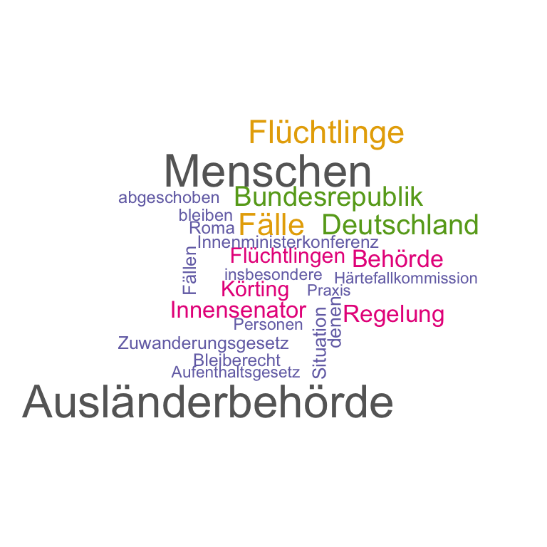

```r
term_colors <- RColorBrewer::brewer.pal(n = 8L, name = "Dark2")
BE$wordcloud(n = 125L, n_words = 25, colors = term_colors)
```

#### Time Series Analysis

The `Topicanalysis` class offers a method for extracting the time series information from the LDA object.

```r
z <- BE$as.zoo(x = 125, aggregation = "year")
is(z)
```

```
## [1] "zoo"
```

Going beyond the plain `as.zoo()`-method, labels can be used.

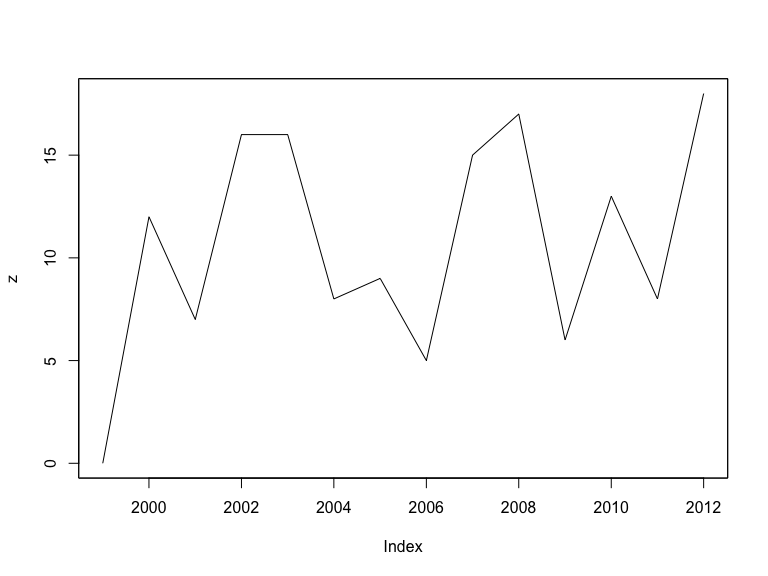

```r
z <- BE$as.zoo(x = "Flucht, Asyl, vorläufiger Schutz", aggregation = "year")
plot(z)
```

#### Cooccurrences

```r
dt <- BE$cooccurrences()
```

```
## ... getting document-topics-matrix
```

```
## ... generating permutations
```

```r
# dt <- BE$cooccurrences(verbose = FALSE) # argument verbose not yet used
```

The table with co-occurrence data can be understood to include relational data. It can be parsed, processed and visualised accordingly using the *igraph* package.

```r
dt_min <- dt[chisquare >= 10.83][!a %in% topics_to_drop][!b %in% topics_to_drop]
g_data = data.frame(
  from = dt_min[["a_label"]],
  to = dt_min[["b_label"]],
  n = dt_min[["count_coi"]],
  stringsAsFactors = FALSE
)
g <- igraph::graph_from_data_frame(g_data, directed = TRUE)
```

At this stage, we have a directed graph, but logically this is not appropriate. We can simplify the graph by turning it into an undirected graph.

```r
g <- igraph::as.undirected(g, mode = "collapse")
g <- igraph::simplify(g, remove.loops = TRUE)
```

The plotting capabilities of the *igraph* package fall behind what other packages (such as DiagrammeR) have on offer. Anyway …

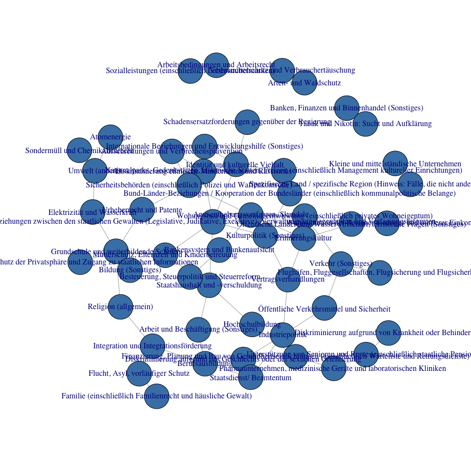

```r
plot.igraph(
  g, shape = "square", vertex.color = "steelblue",
  label = V(g)$name, label.family = 11, label.cex = 0.5
)
```

### Reading

The `read()`-generic method is re-used by the `Topicanalysis`-class and supplemented by additional functionality.

A preliminary step to reading is knowing what you want to read. Let us assume that we want to inspect the documents that combine a reference to refugees and asylum, and on integration. First, we get the topic ids.

```r
topic_flucht <- grep("Flucht", BE_labels)
topic_integration <- grep("Integration", BE_labels)
```

We can then use the `$docs()`-method of the `Topicanalysis`-class to get the documents that combine these topics.

```r
docs <- BE$docs(x = topic_flucht, y = topic_integration)
docs
```

```
## [1] "Lehmann_2003-09-25_1"      "Körting_2005-04-28_4"
## [3] "Björn Jotzo_2009-09-24_2"  "Canan Bayram_2009-09-24_1"
```

The `Topicanalysis`-class has a field `bundle` for a `partition_bundle`. In “real” context, you would include a `partition_bundle` covering the whole corpus. Here, we are much more selective and generate a targetted `partition_bundle` with only those partitions we will want to have a look at. Note that we use regular expressions to extract the metadata (speaker name, date, speech number) from the document labels.

```r
BE$bundle <- as.partition_bundle(lapply(
  docs,
  function(doc){
    who <- gsub("^(.*?)_.*$", "\\1", doc)
    date <- gsub("^.*(\\d{4}-\\d{2}-\\d{2})_\\d+$", "\\1", doc)
    no <- as.integer(gsub("^.*?_(\\d+)$", "\\1", doc))
    p <- partition("BE", who = who, date = date, verbose = FALSE)
    pb <- as.speeches(p, s_attribute_name = "who", verbose = FALSE, progress = FALSE)
    pb[[no]]
}))
```

Now we inspect a document.

```r
BE$read(docs[1], n = 3L, no_token = 100)
```

You can also put this into a loop. For instancde, to make informed judgements whether the content of a document meets expectations, or not. Not that the output generated by calling the `$read()`-method needs to be wrapped into a call to `show()` explicitly in a loop.

```r
labels <- logical(length = length(docs))
for (i in seq_along(docs)){
  fulltext <- BE$read(docs[i], n = 3L, no_token = 100)
  show(fulltext)
  userinput <- menu(choices = c(TRUE, FALSE))
  if (userinput == 0L) break else labels[i] <- c(TRUE, FALSE)[userinput]
}
```

Again, the workflow is somewhat different if we want to include the fulltext output in a Rmarkdown document.

```r
h <- get_highlight_list(BE$topicmodel, partition_obj = BE$bundle[[1]], no_token = 150)
html(BE$bundle[[1]], height = "350px") %>% highlight(highlight = h)
```

## Corpus: BE

### who: Lehmann // date: 2003-09-25 // who: Lehmann

Frau Präsidentin! Meine sehr verehrten Damen und Herren! Als in den 50er Jahren des letzten Jahrhunderts die ersten ausländischen Mitbürgerinnen und Mitbürger in unser Land kamen, ging man davon aus, dass sie nach einigen Jahren in ihre Heimatländer zurückkehren würden. Sie hießen damals dementsprechend “ Gastarbeiter ”. Wie wir heute wissen, erwies sich diese Annahme als Trugschluss. Die überwiegende Mehrheit ist in Deutschland geblieben. Sie holten ihre Familienangehörigen ins Land. Viele dieser Menschen sind in Deutschland geboren worden und haben inzwischen den deutschen Pass. Mittlerweile spricht man von der so genannten vierten Generation. Leider haben wir – und damit meine ich alle Parteien – über Jahrzehnte so getan, als ob sich in dieser Zeit nichts getan hätte. Das Blutsrecht galt bis zur Einführung des neuen Staatsbürgerrechts. Integrationsmaßnahmen waren Mangelware. Dadurch zahlen wir gerade in Berlin teilweise einen hohen Preis. Ich verweise in dem Zusammenhang nur auf die Probleme der Schulen. Viele Probleme wären heute nicht vorhanden, wenn in Deutschland frühzeitig begriffen worden wäre, dass es sich nicht so sehr um Gastarbeiter handelte, sondern um Zuwanderer oder Einwanderer. Das Kennzeichen von Zuwanderern besteht darin, dass sie für viele Jahre oder sogar für immer in Deutschland ihren Lebensmittelpunkt finden. Gerade die Niederlande haben in vielen Bereichen gezeigt, wie es gehen kann. Deutschland ist seit langer Zeit de facto ein Zuwanderungsland. Das ist die Kernaussage, die ich hier machen möchte. Das sollte in diesem Hause eigentlich auch Konsens sein. -LSB- Beifall bei der FDP und den Grünen – Vereinzelter Beifall bei der SPD, der CDU und der PDS -RSB- Es ist deshalb um so bedauerlicher, dass Deutschland noch nicht de jure ein Einwanderungsland ist. Wir haben mit dem Tohuwabohu im Bundesrat und dem abschließenden Urteil des Bundesverfassungsgerichts im Dezember 2002 viel Zeit verloren. Je schneller ein neues Gesetz kommt, desto besser, nicht nur für Zuwanderer, sondern auch für die Deutschen selbst. Auf Deutschland wird in den nächsten Jahrzehnten eine Alterswelle zukommen. Der jüngsten Bevölkerungsprognose des Statistischen Bundesamtes zufolge werden in Deutschland im Jahr 2050 75 Millionen Menschen leben. Sind heute nur 4 % der Deutschen älter als 80 Jahre, werden es 2050 rund 12 % sein. Scheidet die Generation der Babyboomer aus dem Erwerbsleben aus – diejenigen, die zwischen 1950 und 1970 geboren wurden –, werden wir durch permanente Zuwanderung bis 550 000 Personen netto pro Jahr ins Land holen müssen. Eine Anhebung des Renteneintrittsalters auf 67 Jahre würde diese Schwierigkeiten nur um einige Jahre verschieben. Nach einer Statistik der UNO müssten sogar 3,6 Millionen Immigranten pro Jahr nach Deutschland kommen, um das Verhältnis zwischen der Zahl der Beschäftigten und der Rentnerinnen und Rentner auf dem Niveau von 1995 zu halten. Nicht umsonst hat die Europäische Kommission im Juni dieses Jahres die Mitgliedsstaaten dazu aufgefordert, in Sachen Einwanderung und Asyl mehr Großzügigkeit walten zu lassen. Die Devise muss deswegen lauten: legale Einwanderung begünstigen, illegale Einwanderung entschlossen bekämpfen. Das gilt als Devise für die Zukunft. Anders ausgedrückt: Ohne Einwanderung ist es nahezu unmöglich, den wirtschaftlichen Wohlstand in unserem Land weiterhin auf diesem hohen Niveau zu halten. Schon allein aus diesem Grund müsse die Kritiker von Zuwanderung ihre Meinung revidieren. Die aktuell hohe Arbeitslosigkeit macht eine Zuwanderung nicht überflüssig, ganz im Gegenteil. Gezielte und bedarfsorientierte Zuwanderung in bestimmten Branchen und Regionen verschärft nicht die Arbeitslosigkeit, sondern trägt unserer Meinung nach zu einer Lösung bei. Die arbeitsmarktorientierte Zuwanderung ist daher essentiell. In den Mangelberufen soll ein Arbeitsplatz mit einem Zuwanderer nur dann besetzt werden, wenn eine Besetzung des Arbeitsplatzes aus dem deutschen Arbeitsmarkt heraus nicht möglich ist. Dies ist die einzige Möglichkeit, der Bevölkerung ein Zuwanderungsgesetz schmackhaft zu machen. Bei der differenzierten Arbeitsmarktlage macht dies durchaus Sinn. Während in Stuttgart Zuwanderung Sinn macht, wäre es für Berlin, bei unseren katastrophalen Arbeitslosenzahlen, derzeit nicht unbedingt wünschenswert. Die komplette Arbeitsmarktzuwanderung sollte unter eine Jahresquote gestellt werden. Über die Entscheidungsinstanz kann man streiten. Das könnten beispielsweise Bundestag und Bundesrat in Zusammenarbeit mit dem Zuwanderungsrat sein. Der entscheidende Vorteil einer Jahresquote ist, dass sie auch auf Null gedrückt werden kann, wenn Entwicklungen wirtschaftlicher Art es notwendig machen. Die Jahresquote hat aber noch einen anderen Vorteil. Sie kann mit der subjektiven Integrationsbereitschaft unserer Bevölkerung konform gehen. Das ist auf alle Fälle besser als eine ungesteuerte Zuwanderung. Doch eine gesteuerte Zuwanderung hat vor allem eine Aufgabe: die bislang unbefriedigende Integration in Berlin und Deutschland zu verbessern. Denken wir an PISA, denken wir an “ Bärenstark ”, denken wir an die hiesigen Schulen oder ganz generell an die Stadtteile Kreuzberg, Neukölln oder Wedding; die Integration in unsere Gesellschaft ist der Schlüssel für den ökonomischen, ja auch letztendlich persönlichen Erfolg eines jeden. Wir brauchen deshalb eine flächendeckende Einführung von deutschen Orientierungskursen, auch für diejenigen, die schon länger bei uns leben. Hier kann ich den rot-grünen Gesetzentwurf nicht billigen, der lediglich Integrationskurse für neu Zugewanderte anbietet. Eine nachholende Integration würde damit wohl kaum stattfinden. Ein weiterer Punkt betrifft die Kostenfrage. Wer bestellt, sollte bezahlen. Im Gegensatz zum rot-grünen Entwurf sprechen wir uns dafür aus, dass Basiskurse, Orientierungskurse, aber auch die dazu gehörige Kinderbetreuung vom Bund getragen werden. Den Ländern sollte das nicht zugemutet werden. Integration darf allerdings nicht nur ein Recht sein, im Gegenteil. Die Nichtteilnahme an Integrationskursen muss zu Sanktionen führen. Eine Teilnahmepflicht besteht so lange, bis sich der Teilnehmer mündlich und schriftlich in befriedigender Form verständigen kann. Holland hat uns gezeigt, dass bei Nichtteilnahme sogar die Aufenthaltsberechtigung entzogen werden kann. Zuwanderung aus wirtschaftlichen oder anderen Gründen nicht humaner Art ist strikt von Zuwanderung durch Verfolgung bzw. Asyl zu unterscheiden. Wir lehnen die nichtstaatliche und geschlechtsspezifische Verfolgung als Asylgrund ab. Allerdings sprechen wir uns hierbei für das so genannte kleine Asyl und damit für die Anerkennung als Flüchtlinge aus. Lassen Sie mich in diesem Zusammenhang ein Wort zur Abschiebeproblematik sagen. Es ist in den letzten Wochen und Monaten der Eindruck entstanden, dass die Senatsinnenverwaltung oder die Ausländerbehörde rechtswidrig gehandelt haben, als sie Abschiebungen anordneten. Ich warne vor dieser Mythenbildung. Der Senat handelt nach der gegenwärtigen Gesetzeslage. Es ist unverantwortlich, wenn der Eindruck entsteht, die Verantwortlichen würden dadurch in eine juristische Schmuddelecke gedrängt werden. Allerdings kann man auf der anderen Seite auch nachfragen, ob es aus moralischen Gründen und auch im Hinblick auf unsere demographische Entwicklung richtig ist, wenn ein Mensch, der elf Jahre in unserer Stadt lebt, plötzlich abgeschoben wird. Skandalös ist, dass Asylbewerber zu lange auf ihren Bescheid warten müssen. -LSB- Beifall der Frau Abg. Senftleben -LRB- FDP -RRB- -RSB- Auch die teilweise monatelange Tortur in der Abschiebehaft selbst ist niemandem zuzumuten. -LSB- Beifall bei der FDP -RSB- Deshalb appelliere ich an den Senat, hier endlich Abhilfe zu schaffen. Über eine so genannte Altfallregelung für geduldete Flüchtlinge, die seit sechs Jahren straffrei im Land leben und ihren Lebensunterhalt durch eigene Erwerbstätigkeit bestreiten, sollte nachgedacht werden. Ich hätte mir jedenfalls gewünscht, dass es mit einem Zuwanderungsgesetz für den oben genannten Fall eine Lösung gegeben hätte. Der Hamburger Finanzsenator Wolfgang Peiner wünscht sich mehr qualifizierte Zuwanderung in Hamburg. Toronto und Vancouver nannte er dabei als Vorbild. Der Wirtschaftssenator der Hansestadt pflichtet ihm bei und glaubt sogar, dass eine geregelte Zuwanderung die Lebensqualität der Stadt verbessere. Das wünsche ich mir für Berlin auch. Im Übrigen sind beide Hamburger Senatoren Mitglieder der CDU. In diesem Sinne hoffe ich, dass es so schnell wie möglich zu einem vernünftigen und abgewogenen Zuwanderungsgesetz kommt, damit die Gesetzeslage endlich die Realität unseres Landes widerspiegelt. – Vielen Dank! -LSB- Beifall bei der FDP -RSB-

```r
h <- get_highlight_list(BE$topicmodel, partition_obj = BE$bundle[[2]], no_token = 150)
html(BE$bundle[[2]], height = "350px") %>% highlight(highlight = h)
```

## Corpus: BE

### who: Körting // date: 2005-04-28 // who: Körting

Herr Kollege Hahn! Das erfolgt auf der Grundlage des Staatsangehörigkeitsregelungsgesetzes und des geltenden Aufenthaltsrechts. -LSB- Beifall bei der SPD und der PDS -RSB- Herr Kollege Hahn! Da müssen Sie etwas missverstanden haben. -LSB- Hahn -LRB- FDP -RRB-: Meldung der “ taz ”! -RSB- Der Bundesinnenminister kann keinem Menschen die deutsche Staatsangehörigkeit entziehen. Dafür hat er keine Zuständigkeit. Das betrifft übrigens nicht nur Türken, sondern auch Menschen, die mit Amerikanern verheiratet sind, deshalb die amerikanische Staatsangehörigkeit angenommen haben und jetzt zu ihrer Überraschung feststellen, dass sie gleichzeitig die deutsche verloren haben. Man verliert nach dem geltenden Recht, wenn man eine fremde Staatsangehörigkeit annimmt, automatisch die deutsche Staatsangehörigkeit. Da brauche ich keine Entziehung oder wie auch immer. Was der Bundesinnenminister gemacht hat, ist die Bitte an die türkischen Behörden, nachdem bekannt geworden ist, dass es eine Vielzahl von ehemals türkischen Staatsangehörigen, die Deutsche geworden sind, gegeben hat, die dann wieder – wie das früher möglich war – die türkische Staatsangehörigkeit zusätzlich erworben haben, den deutschen Behörden dieses bekannt zu geben, damit man dann mit den Betreffenden über die notwendigen Folgerungen reden kann. Teilweise sieht das Aufenthaltsrecht übrigens, was den Aufenthaltsstatus betrifft, ausdrückliche Vergünstigungen vor. Ehemalige deutsche Staatsangehörige, die die deutsche Staatsangehörigkeit abgelegt haben, haben nach dem Aufenthaltsrecht ein leichteres Verfahren zum Erwerb einer Aufenthaltserlaubnis oder einer Niederlassungserlaubnis. Das ist auch der Schwerpunkt dessen, was ich gegenüber den türkischen Verbänden vorgetragen habe: Wir werden das, was im Aufenthaltsrecht steht, nutzen, um Menschen mit türkischem Migrationshintergrund, die in einer für sie unklaren Situation ab 2000, teilweise auch durch eine falschen Beratung durch türkische Behörden, zusätzlich auch die türkische Staatsangehörigkeit wieder erworben haben, wieder einen klaren Rechtsstatus zu verschaffen. Der klare Rechtsstatus ist erst einmal der Aufenthaltsstatus. Menschen, die seit 40 Jahren hier leben, müssen wieder einen vernünftigen Aufenthaltsstatus haben. Und bei denjenigen, die sich jetzt klar entscheiden wollen: Ich will nicht mehr Türke sein, wenn es keine Doppelstaatsangehörigkeit gibt, sondern ich will nur deutscher Staatsangehöriger sein. –, nutzen wir die Möglichkeiten des Staatsangehörigkeitsrechts, um ihnen die Einbürgerung zu den üblichen Bedingungen – übrigens auch zu den üblichen Gebühren – wieder zu ermöglichen. -LSB- Beifall bei der SPD und der PDS -RSB-

## References

*Computational Social Science : Die Analyse von Big Data*. 2018. 1. Auflage. Baden-Baden: Nomos. http://digitale-objekte.hbz-nrw.de/storage2/2018/07/05/file_29/8054377.pdf.